# Coursera ML Project

A-C TREGOUET

5/8/2017

# Weight Lifting Exercise

The goal is to predict how well a weight lifting exercise is done, using sensor’s data.

## Setting R project

- install packages : munsell, caret, randomForest, gbm, survival, splines, plyr, doMC, doParallel
- download libraries : ggplot2, caret, gbm, survival, splines, plyr, doMC, randomForest, parallel, doParallel
- configure parallel processing (see [this post](https://github.com/lgreski/datasciencectacontent/blob/master/markdown/pml-randomForestPerformance.md) )

## Retrieveing source files and creating datasets

There are 2 datasets : *pml-training.csv* and *pml-testing.csv*

*pml-testing.csv* contains observations without the outcome, because the goal here is to predict it. So, I will not use this data set to build the model : it’s the guessing set.

To evaluate the model, cross validation is needed, so I will split the *pml-training.csv* into a training set and a testing set. The model will be built using training set, and validated/evaluated using testing set. At the end, the model will be used on guessing set to predict 20 observations.

```r
sourceFile <- read.csv("~/Desktop/pml-training.csv")
inTrain <- createDataPartition(y=sourceFile$classe, p=0.7, list=FALSE)
training <- sourceFile[inTrain,]
testing <- sourceFile[-inTrain,]
guessing <- read.csv("~/Desktop/pml-testing.csv")
```

## Cleaning dataset

### There’s too much variables

Let’s see how much variables contains data sets :

```r
dim(training)
```

```
## [1] 13737   160
```

There are 160 variables, which is huge! First, my goal is to reduce the number of predictors.

### Excluding variables with lot of missing values

Looking brievly at data using…

```
summary(training)
head(training)
```

…it seems there are a lot of NA, blank and “#DIV/0!” values. I all replace them by NA in the training set, and look how many variables have more than 90% of missing values :

```r
training[training==""] <- NA
training[training=="#DIV/0!"] <- NA
dim(training[colMeans(is.na(training))>0.9])
```

```
## [1] 13737   100
```

100 variables contains 90% missing values! They are not relevant enough, so I exclude them from the training set :

```r
columsToKeep <- colnames(training[colMeans(is.na(training))<0.9])
training <- training[,columsToKeep]
dim(training)
```

```
## [1] 13737    60
```

Now the training set contains 60 variables.

### Excluding data out of context

The goal is to predict the outcome with sensor’s parameters. So, I thinkk I can exclude all variables that are relative to test executions (like id, datetime, window, username) :

```r
training <- training[,-c(1:7)]
dim(training)
```

```
## [1] 13737    53
```

Now the training set contains 53 variables.

### Variables correlation

Does the training set contain lot ofcorrelated variables ?

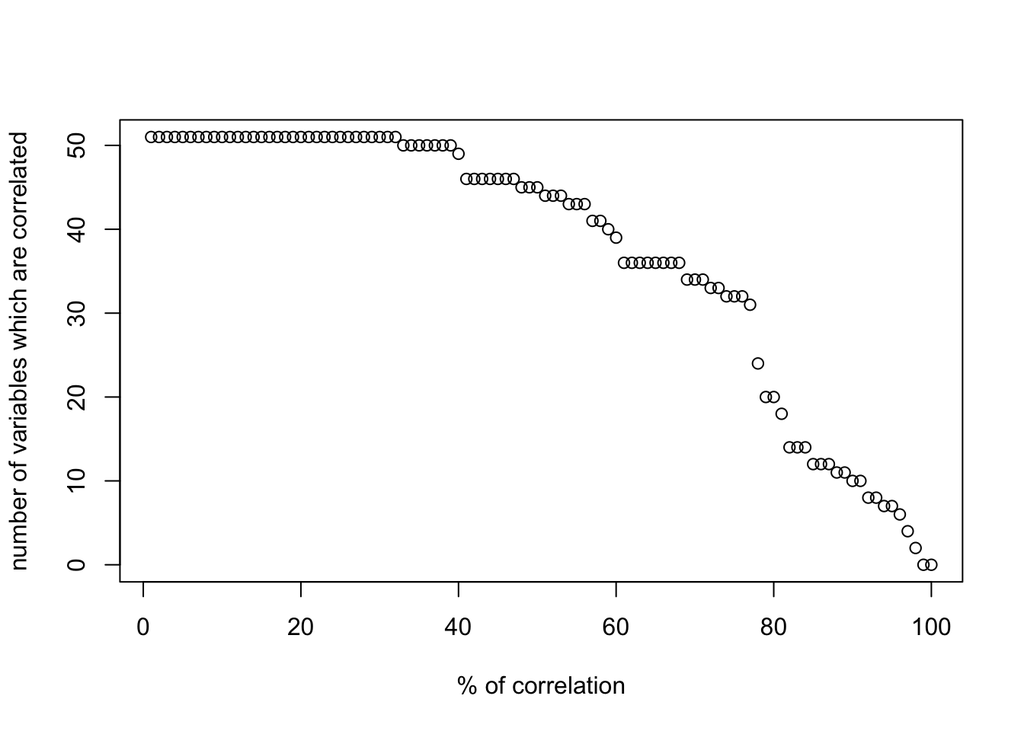

```r
corr <- 1:100
diplayCor <- 1:100
M <- abs(cor(training[,-c(1, dim(training))]))
for (indexCor in 1:100){
  diplayCor[indexCor] <- length(unique(rownames(which(M > indexCor/100 & M < 1,arr.ind = T))))
}
plot(diplayCor, xlab="% of correlation", ylab = "number of variables which are correlated")
```

On the chart, I can guess that about 30 variables are highly (more than 70%) correlated. I can suppose that variables of training set could be summarized into several variables only. I will give a try to preprocess data using PCA.

## Preprocessing data (with PCA)

I apply PCA in order to keep 90% of data information :

```r
preProcPCA <- preProcess(training[,-dim(training)],method = "pca", tresh=0.9)
predPCA <- predict(preProcPCA,training[,-dim(training)])
```

Instead of having 53 variables, PCA results indicated that training set could be sumarized by 25 variables.

## Applying operations on testing set

On the testing set, I exclude the same variables I exluded in the training set :

```r
testing <- testing[,columsToKeep]
testing <- testing[,-c(1:7)]
dim(testing)
```

```
## [1] 5885   53
```

I check that test set now have 53 variables too.

And now I apply PCA from training set to testing set :

```r
testPCA <- predict(preProcPCA,testing[,-dim(testing)])
```

## Building models

Random forests and boostings often are the top performance algorithms for classification predictions. I will apply them with and without preprocessing with PCA.

Computation duration of each model building is quite long. I decided to save it and to include it in model comparisons. Computation durations are calculated this way :

```
start.time <- Sys.time()
{ ... building the model ... }
end.time <- Sys.time()
timeModel <- difftime(end.time, start.time, units="mins")
```

I will first build every model separately and then compare them.

### Random forest

#### Random forest without preprocessing with PCA

I create the model :

```r
start.time <- Sys.time()
modelFitRF <- randomForest(classe ~ ., data=training, importance=TRUE, proximity=TRUE)
end.time <- Sys.time()
timeRF <- difftime(end.time, start.time, units="mins")
modelFitRF
```

```
##
## Call:
##  randomForest(formula = classe ~ ., data = training, importance = TRUE,      proximity = TRUE)
##                Type of random forest: classification
##                      Number of trees: 500
## No. of variables tried at each split: 7
##
##         OOB estimate of  error rate: 0.53%
## Confusion matrix:
##      A    B    C    D    E  class.error
## A 3903    2    0    0    1 0.0007680492
## B   19 2636    3    0    0 0.0082768999
## C    0   13 2380    3    0 0.0066777963
## D    0    0   23 2227    2 0.0111012433
## E    0    0    2    5 2518 0.0027722772
```

*Note : using caret ‘train’ function was too long, that’s why I choose ‘randomForest’.*

I apply the built model to the testing set, and compare predictions to reality :

```r
finalPredictionRF <- predict(modelFitRF,testing)
confRF <- confusionMatrix(testing$classe,finalPredictionRF)
confRF
```

```
## Confusion Matrix and Statistics
##
##           Reference
## Prediction    A    B    C    D    E
##          A 1674    0    0    0    0
##          B    4 1133    2    0    0
##          C    0    1 1025    0    0
##          D    0    0    8  955    1
##          E    0    0    3    0 1079
##
## Overall Statistics
##
##                Accuracy : 0.9968
##                  95% CI : (0.995, 0.9981)
##     No Information Rate : 0.2851
##     P-Value [Acc > NIR] : < 2.2e-16
##
##                   Kappa : 0.9959
##  Mcnemar's Test P-Value : NA
##
## Statistics by Class:
##
##                      Class: A Class: B Class: C Class: D Class: E
## Sensitivity            0.9976   0.9991   0.9875   1.0000   0.9991
## Specificity            1.0000   0.9987   0.9998   0.9982   0.9994
## Pos Pred Value         1.0000   0.9947   0.9990   0.9907   0.9972
## Neg Pred Value         0.9991   0.9998   0.9973   1.0000   0.9998
## Prevalence             0.2851   0.1927   0.1764   0.1623   0.1835
## Detection Rate         0.2845   0.1925   0.1742   0.1623   0.1833
## Detection Prevalence   0.2845   0.1935   0.1743   0.1638   0.1839
## Balanced Accuracy      0.9988   0.9989   0.9936   0.9991   0.9992
```

```r
accRF <- confRF$overall['Accuracy']
```

#### Random forest with preprocessing with PCA

I create the model :

```r
start.time <- Sys.time()
modelFitPCARF <- train(y=training$classe,method="rf",x=predPCA, trControl = fitControl)
end.time <- Sys.time()
timePCARF <- difftime(end.time, start.time, units="mins")
modelFitPCARF$finalModel
```

```
##
## Call:
##  randomForest(x = x, y = y, mtry = param$mtry)
##                Type of random forest: classification
##                      Number of trees: 500
## No. of variables tried at each split: 2
##
##         OOB estimate of  error rate: 2.56%
## Confusion matrix:
##      A    B    C    D    E class.error
## A 3878   10   11    5    2 0.007168459
## B   49 2571   33    2    3 0.032731377
## C    7   37 2318   31    3 0.032554257
## D    5    2   97 2143    5 0.048401421
## E    1   15   19   15 2475 0.019801980
```

I apply the built model to the testing set, and compare predictions to reality :

```r
finalPredictionPCARF <- predict(modelFitPCARF,testPCA)
confPCARF <- confusionMatrix(testing$classe,finalPredictionPCARF)
confPCARF
```

```
## Confusion Matrix and Statistics
##
##           Reference
## Prediction    A    B    C    D    E
##          A 1663    4    4    2    1
##          B   20 1103   14    1    1
##          C    1   13 1005    7    0
##          D    2    2   49  908    3
##          E    0    1    8    4 1069
##
## Overall Statistics
##
##                Accuracy : 0.9767
##                  95% CI : (0.9725, 0.9804)
##     No Information Rate : 0.2865
##     P-Value [Acc > NIR] : < 2.2e-16
##
##                   Kappa : 0.9705
##  Mcnemar's Test P-Value : 6.064e-08
##
## Statistics by Class:
##
##                      Class: A Class: B Class: C Class: D Class: E
## Sensitivity            0.9864   0.9822   0.9306   0.9848   0.9953
## Specificity            0.9974   0.9924   0.9956   0.9887   0.9973
## Pos Pred Value         0.9934   0.9684   0.9795   0.9419   0.9880
## Neg Pred Value         0.9945   0.9958   0.9846   0.9972   0.9990
## Prevalence             0.2865   0.1908   0.1835   0.1567   0.1825
## Detection Rate         0.2826   0.1874   0.1708   0.1543   0.1816
## Detection Prevalence   0.2845   0.1935   0.1743   0.1638   0.1839
## Balanced Accuracy      0.9919   0.9873   0.9631   0.9868   0.9963
```

```r
accPCARF <- confPCARF$overall['Accuracy']
```

### Boosting

#### Boosting without preprocessing with PCA

I create the model :

```r
start.time <- Sys.time()
modelFitGBM <- train(y=training$classe,method="gbm",x=training)
end.time <- Sys.time()
timeGBM <- difftime(end.time, start.time, units="mins")
modelFitGBM
```

```
## Stochastic Gradient Boosting
##
## 13737 samples
##    53 predictor
##     5 classes: 'A', 'B', 'C', 'D', 'E'
##
## No pre-processing
## Resampling: Bootstrapped (25 reps)
## Summary of sample sizes: 13737, 13737, 13737, 13737, 13737, 13737, ...
## Resampling results across tuning parameters:
##
##   interaction.depth  n.trees  Accuracy  Kappa
##   1                   50      1         1
##   1                  100      1         1
##   1                  150      1         1
##   2                   50      1         1
##   2                  100      1         1
##   2                  150      1         1
##   3                   50      1         1
##   3                  100      1         1
##   3                  150      1         1
##
## Tuning parameter 'shrinkage' was held constant at a value of 0.1
##
## Tuning parameter 'n.minobsinnode' was held constant at a value of 10
## Accuracy was used to select the optimal model using  the largest value.
## The final values used for the model were n.trees = 50, interaction.depth
##  = 1, shrinkage = 0.1 and n.minobsinnode = 10.
```

I apply the built model to the testing set, and compare predictions to reality :

```r
finalPredictionGBM <- predict(modelFitGBM,testing)
confGBM <- confusionMatrix(testing$classe,finalPredictionGBM)
confGBM
```

```
## Confusion Matrix and Statistics
##
##           Reference
## Prediction    A    B    C    D    E
##          A 1674    0    0    0    0
##          B    0 1139    0    0    0
##          C    0    0 1026    0    0
##          D    0    0    0  964    0
##          E    0    0    0    0 1082
##
## Overall Statistics
##
##                Accuracy : 1
##                  95% CI : (0.9994, 1)
##     No Information Rate : 0.2845
##     P-Value [Acc > NIR] : < 2.2e-16
##
##                   Kappa : 1
##  Mcnemar's Test P-Value : NA
##
## Statistics by Class:
##
##                      Class: A Class: B Class: C Class: D Class: E
## Sensitivity            1.0000   1.0000   1.0000   1.0000   1.0000
## Specificity            1.0000   1.0000   1.0000   1.0000   1.0000
## Pos Pred Value         1.0000   1.0000   1.0000   1.0000   1.0000
## Neg Pred Value         1.0000   1.0000   1.0000   1.0000   1.0000
## Prevalence             0.2845   0.1935   0.1743   0.1638   0.1839
## Detection Rate         0.2845   0.1935   0.1743   0.1638   0.1839
## Detection Prevalence   0.2845   0.1935   0.1743   0.1638   0.1839
## Balanced Accuracy      1.0000   1.0000   1.0000   1.0000   1.0000
```

```r
accGBM <- confGBM$overall['Accuracy']
```

#### Boosting with preprocessing with PCA

I create the model :

```r
start.time <- Sys.time()
modelFitPCAGBM <- train(y=training$classe,method="gbm",x=predPCA)
end.time <- Sys.time()
timePCAGBM <- difftime(end.time, start.time, units="mins")
modelFitPCAGBM
```

```
## Stochastic Gradient Boosting
##
## 13737 samples
##    25 predictor
##     5 classes: 'A', 'B', 'C', 'D', 'E'
##
## No pre-processing
## Resampling: Bootstrapped (25 reps)
## Summary of sample sizes: 13737, 13737, 13737, 13737, 13737, 13737, ...
## Resampling results across tuning parameters:
##
##   interaction.depth  n.trees  Accuracy   Kappa
##   1                   50      0.5526126  0.4247131
##   1                  100      0.6094274  0.5012878
##   1                  150      0.6425016  0.5445471
##   2                   50      0.6499487  0.5542475
##   2                  100      0.7178758  0.6417659
##   2                  150      0.7581354  0.6932716
##   3                   50      0.7088847  0.6302887
##   3                  100      0.7785139  0.7192163
##   3                  150      0.8139467  0.7642742
##
## Tuning parameter 'shrinkage' was held constant at a value of 0.1
##
## Tuning parameter 'n.minobsinnode' was held constant at a value of 10
## Accuracy was used to select the optimal model using  the largest value.
## The final values used for the model were n.trees = 150,
##  interaction.depth = 3, shrinkage = 0.1 and n.minobsinnode = 10.
```

I apply it to the testing set, and compare predictions to reality :

```r
finalPredictionPCAGBM <- predict(modelFitPCAGBM,testPCA)
confPCAGBM <- confusionMatrix(testing$classe,finalPredictionPCAGBM)
confPCAGBM
```

```
## Confusion Matrix and Statistics
##
##           Reference
## Prediction    A    B    C    D    E
##          A 1518   33   53   60   10
##          B  141  810  106   31   51
##          C   43   73  862   24   24
##          D   33   25  137  756   13
##          E   23   89   78   45  847
##
## Overall Statistics
##
##                Accuracy : 0.8144
##                  95% CI : (0.8043, 0.8243)
##     No Information Rate : 0.2987
##     P-Value [Acc > NIR] : < 2.2e-16
##
##                   Kappa : 0.765
##  Mcnemar's Test P-Value : < 2.2e-16
##
## Statistics by Class:
##
##                      Class: A Class: B Class: C Class: D Class: E
## Sensitivity            0.8635   0.7864   0.6974   0.8253   0.8963
## Specificity            0.9622   0.9322   0.9647   0.9581   0.9524
## Pos Pred Value         0.9068   0.7112   0.8402   0.7842   0.7828
## Neg Pred Value         0.9430   0.9536   0.9230   0.9675   0.9796
## Prevalence             0.2987   0.1750   0.2100   0.1556   0.1606
## Detection Rate         0.2579   0.1376   0.1465   0.1285   0.1439
## Detection Prevalence   0.2845   0.1935   0.1743   0.1638   0.1839
## Balanced Accuracy      0.9128   0.8593   0.8311   0.8917   0.9244
```

```r
accPCAGBM <- confPCAGBM$overall['Accuracy']
```

## Comparing models

So now each model have been built, here is a summary of their accuracy and computation duration :

| Preprocessing PCA | Random Forest | Boosting |
| --- | --- | --- |
| No | accuracy : 0.9967715 | accuracy : 1 |
| No | computing duration : 6.6110597 min | computing duration : 13.928558 min |
| Yes | accuracy : 0.9767205 | accuracy : 0.8144435 |
| Yes | computing duration : 8.7958969 min | computing duration : 8.5581972 min |

We can plot this information :

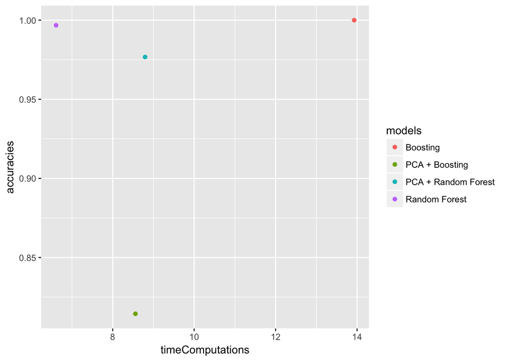

```r
timeComputations <- c(timeRF,timePCARF,timeGBM,timePCAGBM)
accuracies <- c(accRF,accPCARF,accGBM,accPCAGBM)
models <- c("Random Forest", "PCA + Random Forest", "Boosting", "PCA + Boosting")
colors <- c('red', 'blue', 'green',' brown')
comparisons <- data.frame(timeComputations, accuracies, models,colors)
qplot(timeComputations,accuracies,colour=models,data=comparisons)
```

Balancing models accuracy VS their computation duration, the best models seem to be Random Forest and Boosting.

Nevertheless, the 100% accuracy of Boosting model is weird. I fear overfitting of boosting model, so I will finally consider Random Forest model. But I’d be curious to see confrontation of predictions between these two models on the guessing set.

# Predictions

## Applying operations on guessing set

On the guessing set, I exclude the same variables I exluded in the training set :

```r
columsToKeep[columsToKeep=="classe"] <- "problem_id"
guessing <- guessing[,columsToKeep]
guessing <- guessing[,-c(1:7)]
guessing <- guessing[,-c(53)]
dim(guessing)
```

```
## [1] 20 52
```

I check that guessing set now have 52 variables (53 without ‘classe’ variable)

```r
finalPrediction <- predict(modelFitRF,guessing)
finalPredictionGBMTest <- predict(modelFitGBM,guessing)
confusionMatrix(finalPrediction,finalPredictionGBMTest)
```

```
## Confusion Matrix and Statistics
##
##           Reference
## Prediction A B C D E
##          A 7 0 0 0 0
##          B 8 0 0 0 0
##          C 1 0 0 0 0
##          D 1 0 0 0 0
##          E 3 0 0 0 0
##
## Overall Statistics
##
##                Accuracy : 0.35
##                  95% CI : (0.1539, 0.5922)
##     No Information Rate : 1
##     P-Value [Acc > NIR] : 1
##
##                   Kappa : 0
##  Mcnemar's Test P-Value : NA
##
## Statistics by Class:
##
##                      Class: A Class: B Class: C Class: D Class: E
## Sensitivity              0.35       NA       NA       NA       NA
## Specificity                NA      0.6     0.95     0.95     0.85
## Pos Pred Value             NA       NA       NA       NA       NA
## Neg Pred Value             NA       NA       NA       NA       NA
## Prevalence               1.00      0.0     0.00     0.00     0.00
## Detection Rate           0.35      0.0     0.00     0.00     0.00
## Detection Prevalence     0.35      0.4     0.05     0.05     0.15
## Balanced Accuracy          NA       NA       NA       NA       NA
```

I can notice that predictions using Random Forest and Boosting are really not the same, confirming my hypothesis of a not reliable Boosting model (maybe overfitting).

So I use Random Forest model to predict the 20 observations. Here is the final result :

```r
head(finalPrediction, length(finalPrediction))
```

```
##  1  2  3  4  5  6  7  8  9 10 11 12 13 14 15 16 17 18 19 20
##  B  A  B  A  A  E  D  B  A  A  B  C  B  A  E  E  A  B  B  B
## Levels: A B C D E
```